# Survey on ethics regarding AI-generated art

Data Acquisition and Survey Methods

Nikolaus Czernin, Aliakseyeu Dzimitry

# Requirements (delete)

Survey data analysis, report & presentation:

- **Exploratory Data Analysis**: Choose appropriate methods to explore the categorical and quantitative features in your data set (one visualization per research question). Briefly explain the methods and comment on your findings.
- **Descriptive Inference**: Compute suitable summary statistics and display the results in a table.
- **Analytic Inference**: Select an appropriate test statistic to test your hypothesis. Summarize the results and explain how your findings are connected to your research question.

Guidelines for the report:

- use RMarkdown
- include a table of contents
- briefly summarize the functions used
- display all important code snippets in the .pdf
- document your findings

Submit both the .rmd and .pdf files via TUWEL.

```r
ans <- read.delim("answers.csv", sep = ";")
names(ans) <- c("gender", "age", "program", "a1", "a2", "a3")

ans <- ans %>%
  # rename the answer cols and transform them
  mutate(
    revenue.deserved = str_extract(a1, "[:digit:]*") %>% as.numeric(),
    is.artist = a2 %>% as.factor(),
    would.boycott = a3 %>% as.factor()
    ) %>%
  select(-a1, -a2, -a3)

# recode the factor levels of the longer answers
levels(ans$is.artist) <- c("I'm an artist", "I enjoy creating art",
                                "I created some art,\nnot passionately", "I do not create art")
# reverse the levels
ans$is.artist <- ans$is.artist %>% fct_rev()
# rearrange the factor levels of the text answers
# levels(ans$is.artist) = c(4, 3, 2, 1) # the levels for is.artist arrange themselves perfectly somehow; 1 is no art, 4 is max art
# levels(ans$would.boycott) = c(0, 1, 2)

# fill the single NA value in the revenue.deserved column with the median value
ans <- ans %>% mutate(across(revenue.deserved, ~replace_na(., median(., na.rm=TRUE))))


# assigning short variable names to the questions
q1_varname <- "Percentage of generated revenue granted to trained on artist"
q2_varname <- "Respondents' relationships to creating art"
q3_varname <- "Respondents' propensity to boycott unpaid AI-generated art training"
```

|  | gender | age | program | revenue.deserved | is.artist | would.boycott |
| --- | --- | --- | --- | --- | --- | --- |
| 1 | female | 23 | Data Science / MSc / TU Wien | 90 | I do not create art | Yes |
| 2 | male | 21 | Data Science / MSc / TU Wien | 70 | I do not create art | No |
| 3 | female | 23 | Data Science / MSc / TU Wien | 0 | I do not create art | No |
| 4 | female | 24 | Data Science / MSc / TU Wien | 80 | I do not create art | Yes |
| 5 | male | 22 | Data Science / MSc / TU Wien | 20 | I created some art,\nnot passionately | No |
| 6 | male | 25 | Data Science | 90 | I do not create art | No |

```
    gender               age          program          revenue.deserved
 Length:38          Min.   :21.00   Length:38          Min.   :  0.00
 Class :character   1st Qu.:23.00   Class :character   1st Qu.: 40.00
 Mode  :character   Median :24.00   Mode  :character   Median : 60.00
                    Mean   :25.97                      Mean   : 56.89
                    3rd Qu.:26.75                      3rd Qu.: 80.00
                    Max.   :46.00                      Max.   :100.00
                                 is.artist
 I do not create art                  :27
 I created some art,\nnot passionately: 5
 I enjoy creating art                 : 4
 I'm an artist                        : 2


                          would.boycott
 No                              :19
 Only if I really like the artist: 8
 Yes                             :11
```

## Research hypothesis 1

*Artists/authors would credit other artists/authors to more money, if the model were trained on them, than non-artists/non-authors.*

### Exploring the nature of the data/responses

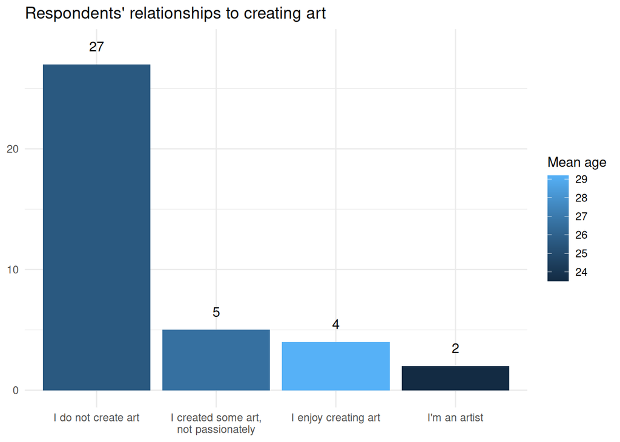

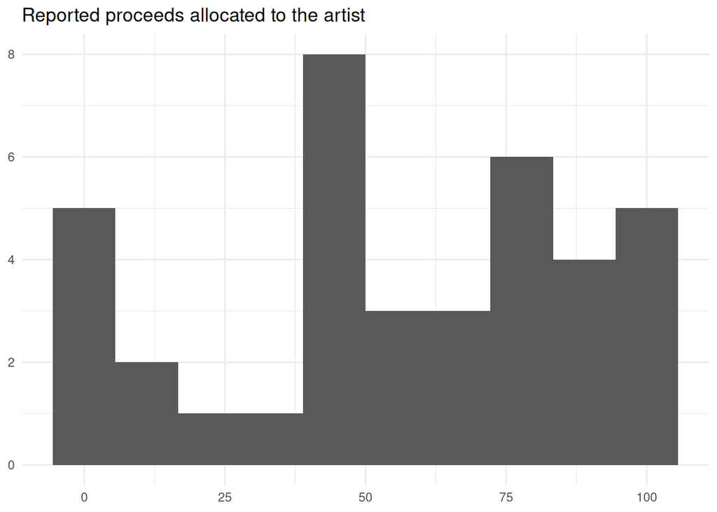

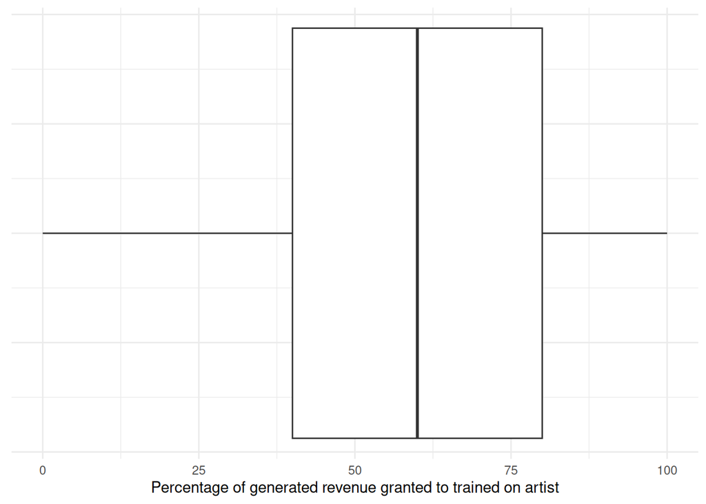

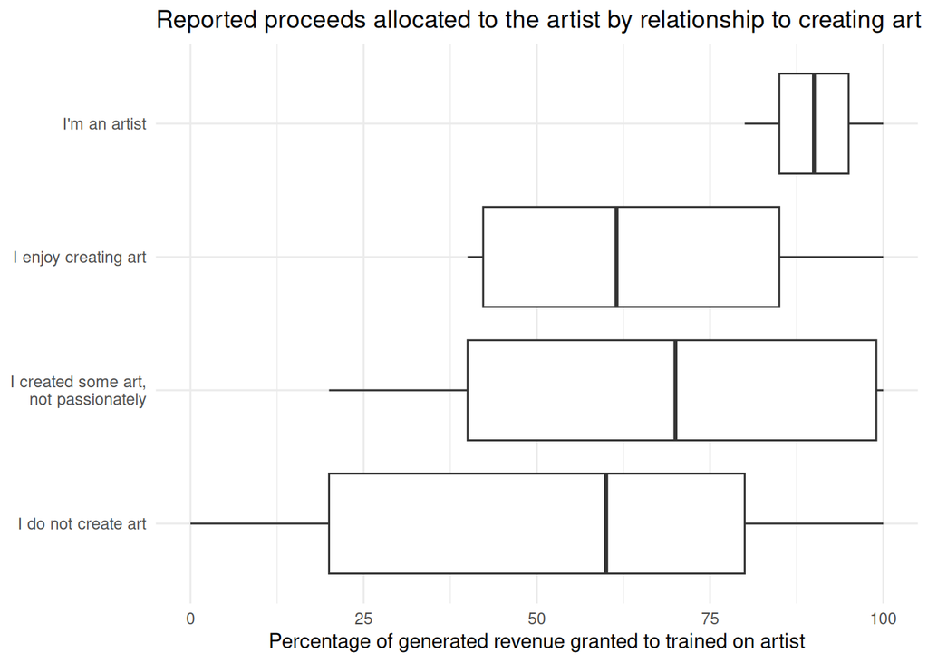

### Independence testing.

```r
k <- 5
# cut the revenue.deserved values into k levels: low to high
ans$revenue.deserved.cat = split_quantile(ans$revenue.deserved, type=k)
table(ans$revenue.deserved.cat, ans$is.artist) %>%
  print() %>%
  chisq.test()
```

```
    I do not create art I created some art,\nnot passionately
  1                   7                                     1
  2                   6                                     1
  3                   5                                     1
  4                   5                                     0
  5                   4                                     2

    I enjoy creating art I'm an artist
  1                    0             0
  2                    2             0
  3                    0             0
  4                    1             1
  5                    1             1
```

```
    Pearson's Chi-squared test

data:  .
X-squared = 8.6727, df = 12, p-value = 0.7306
```

```r
# what if we replicated that data with the same results?
table(ans$revenue.deserved.cat, ans$is.artist) %>%
  chisq.test(simulate.p.value = TRUE)
```

```
    Pearson's Chi-squared test with simulated p-value (based on 2000
    replicates)

data:  .
X-squared = 8.6727, df = NA, p-value = 0.8161
```

We conducted chi-squared tests to examine the independence of the percentage of revenue a respondent would grant an artist, that the generative model had been trained on and the respondent’s relationship to creating art themselves. We recoded the granted.revenue variable to the quintiles. To correct for the low sample size, we run the test with replicates. The resulting p-values were ~0.7 and ~0.8, which exceed the conventional significance level of 0.05. As a result, there is insufficient evidence to reject the null hypothesis of independence, even when using replicates. A bigger pool of respondents may have yielded different results, after all, only 6 of the respondents claimed to be somewhat passionate about creating art.

## Research hypothesis 2

*Artists/authors are, compared to non-artists/non-authors, more inclined to boycott art that was created by a model that trained on an artist, if the artist doesn’t get any money out of it*

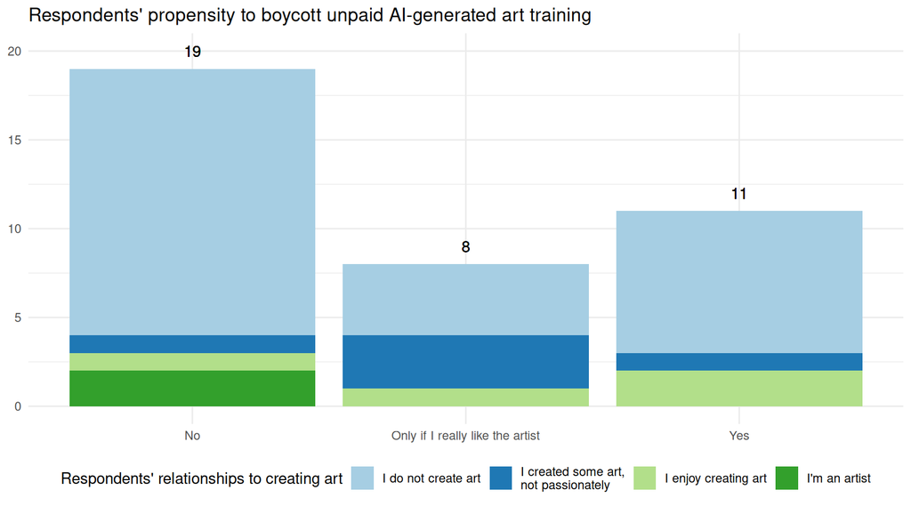

Turns out, exactly half of the respondents would consider boycotting a piece of AI-generated art, if the trained-on artist was not compensated for his contribution. Some of them only if they already really liked the artist.

Maybe more surprisingly, the two respondents claiming to be artists themselves answered not to be wanting to boycott such art.

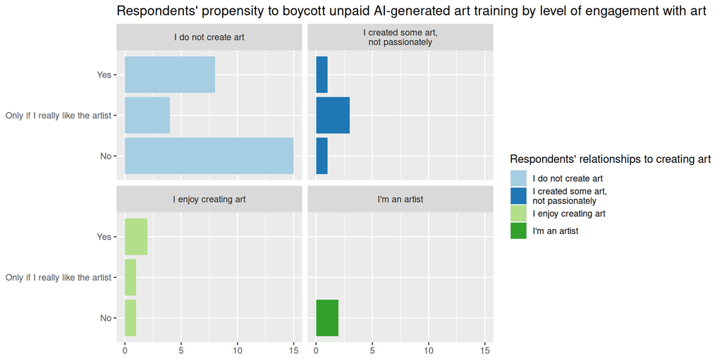

```r
# step 1

ggplot(ans, aes(y=would.boycott, fill=is.artist)) +
  geom_bar() +
    scale_fill_brewer(palette="Paired") +
  labs(y = NULL, x=NULL,
       title=q3_varname %>% paste( "by level of engagement with art"),
       fill=q2_varname
       ) +
  facet_wrap(~ is.artist)
```

### Independence testing.

From looking at the above barplots, we cannot make out a clear pattern of who is more likely to boycott art visually.

```r
# cut the revenue.deserved values into k levels: low to high
table(ans$would.boycott, ans$is.artist) %>%
  print() %>%
  chisq.test()
```

```
                                   I do not create art
  No                                                15
  Only if I really like the artist                   4
  Yes                                                8

                                   I created some art,\nnot passionately
  No                                                                   1
  Only if I really like the artist                                     3
  Yes                                                                  1

                                   I enjoy creating art I'm an artist
  No                                                  1             2
  Only if I really like the artist                    1             0
  Yes                                                 2             0
```

```
    Pearson's Chi-squared test

data:  .
X-squared = 8.453, df = 6, p-value = 0.2068
```

```r
# what if we replicated that data with the same results?
table(ans$would.boycott, ans$is.artist) %>%
  chisq.test(simulate.p.value = TRUE)
```

```
    Pearson's Chi-squared test with simulated p-value (based on 2000
    replicates)

data:  .
X-squared = 8.453, df = NA, p-value = 0.2169
```

Independence testing suggests that in our sample the artists are no more likely to boycott automatically generated content that does not credit the author of its training material than the non-artists. Attempting to account for the low sample size does not yield a significant difference. One must speculate if a non-representative sample of mostly data science students played a role. A point of further research might be to replicate the study with a representative sample; or indeed to sample each category independently.

## Research hypothesis 3

*There is no statistical connection between people who would grant artists/authors more money (question 1) and people who would boycott an AI-generated piece of art, that the trained-on artist did not make any money from, meaning that respondents, while they may agree with the ethical worries of artists regarding AI-generated art, they do not act upon those values.*

### Exploring the data

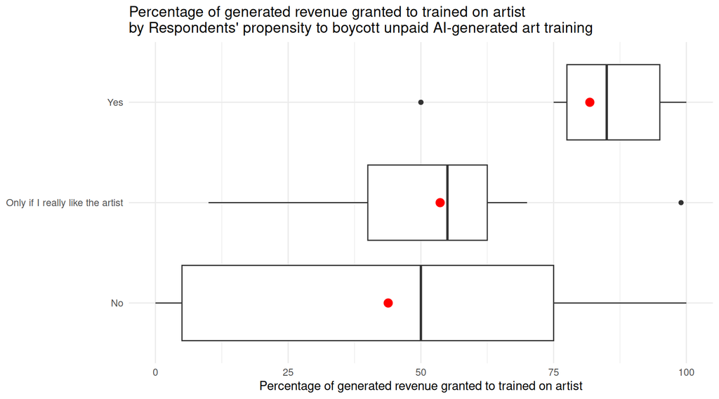

```r
ans %>%
  ggplot(aes(x=revenue.deserved, y=would.boycott)) +
    geom_boxplot() +
    theme_minimal() +
    ylab(NULL) +
    stat_summary(fun.y=mean, geom="point", shape=20, size=5, color="red") +
    ggtitle(q1_varname %>% paste("\nby", q3_varname)) +
    xlab(q1_varname)
```

Looking at the parallel boxplots, we can make out a difference in distribution for revenue percentages credited to trained-on artists for the boycotters and non-boycotters. The median and mean (red dots) values for the respondents willing to boycott such art are higher than for the ones not willing to. The respondents who would not boycott art created from unpaid training is all over, while the respondents who would boycott it, appear to be credit the artists more of the generated revenue.

A different perspective on the answer options would be, that perhaps the difference in distributions is only there, because of the separation of “Yes” answers. Regardless, when joining the answers, “Yes” and “Only if I really like the artist”, the overall distribution of the answers in regards of granted revenue looks not so similar.

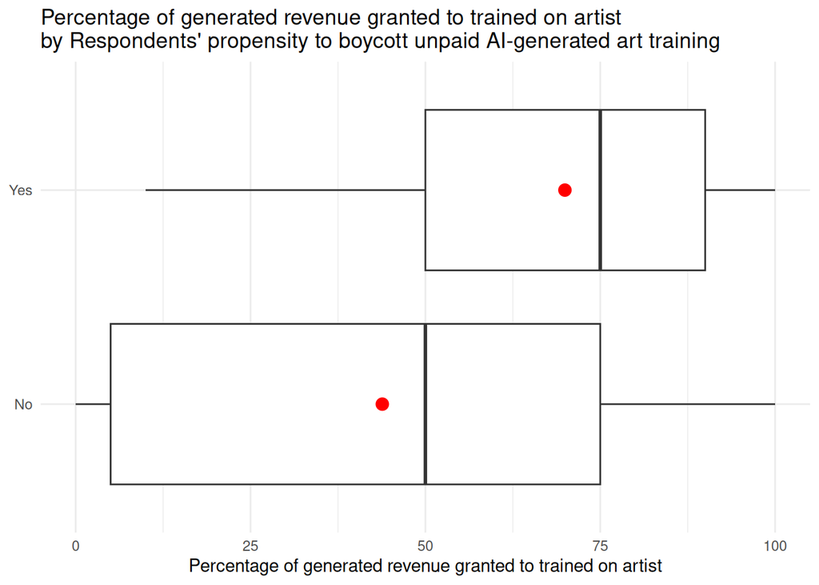

```r
ans$would.boycott.2 <- ans$would.boycott %>% fct_lump_min(16, other_level="Yes")

ans %>%
ggplot(aes(x=revenue.deserved, y=would.boycott.2)) +
  geom_boxplot() +
  theme_minimal() +
  stat_summary(fun.y=mean, geom="point", shape=20, size=5, color="red") +
  ylab(NULL) +
  ggtitle(q1_varname %>% paste("\nby", q3_varname)) +
  xlab(q1_varname)
```

The differences in mean are as follows:

| would.boycott | Mean credited revenue |
| --- | --- |
| No | 43.84211 |
| Only if I really like the artist | 53.62500 |
| Yes | 81.81818 |

| would.boycott.2 | Mean credited revenue |
| --- | --- |
| No | 43.84211 |
| Yes | 69.94737 |

### Testing the differences in means

Starting out by testing the difference in means of the two groups:  
Respondents that would boycott and those that would not.

The response values are not normally distributed, therefore we use a non-parametric test, namely a Wilcoxon test.

```r
wilcox.test(
  filter(ans, would.boycott.2=="Yes")$revenue.deserved,
  filter(ans, would.boycott.2=="No")$revenue.deserved,
  paired = TRUE, alternative = "two.sided"
  ,exact = FALSE
  )
```

```
    Wilcoxon signed rank test with continuity correction

data:  filter(ans, would.boycott.2 == "Yes")$revenue.deserved and filter(ans, would.boycott.2 == "No")$revenue.deserved
V = 135, p-value = 0.03268
alternative hypothesis: true location shift is not equal to 0
```

The test yields a p-value of <0.033, which lets us reject the Null-Hypothesis that there is no difference in means of granted revenue percentage between the groups.  
We can therefore confirm that for our sample, the respondents that are inclined to boycott a piece of art, if the original, trained-on artist did not get compensated, would also grant them a higher portion of the revenue that would have been generated from said piece of art.

### Exploring the non-boycotting group further

The results is not surprising, we in fact were trying to make out, whether respondents that would grant the artists a greater portion of the generated revenue would even consider boycotting the AI-generated piece, determining if the ethical values would be even acted upon.

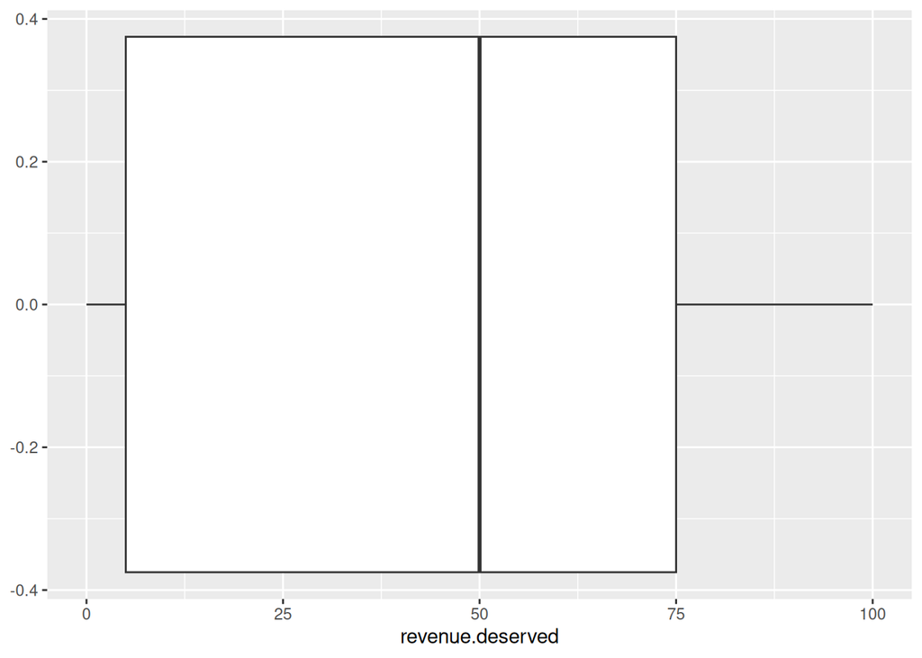

```r
non.boycotter <- ans %>%
  filter(would.boycott == "No")

p1 <- non.boycotter %>%
  ggplot(aes(x=revenue.deserved)) +
  geom_boxplot()
p2 <- non.boycotter %>%
  ggplot(aes(x=revenue.deserved)) +
  geom_histogram()

p1 %>% print()
```

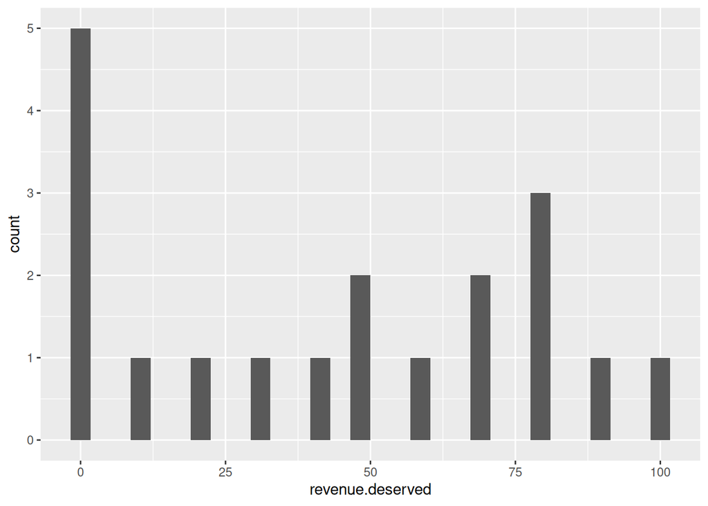

```r
p2 %>% print()
```

```r
# ggarrange(p1, p2, nrow=2)
```

The non-boycotters’ percentages of revenue granted to trained-on artists, is quite evenly distributed. Seeing as we are only looking at a total of 19 respondents, we are far from being able to make a generalizing statement to answer the original question.